# Final Project

Ziwen Zhang

2023-07-29

## Background:

The data set is a simulated data set. It represents the data on COVID+ patients (i.e. patients diagnosed with COVID) who were hospitalized in the New York Presbyterian hospital (Weill Cornell and Lower Manhattan campus). Some COVID+ patients suffer from acute respiratory distress and have acute difficulties in breathing. Such critically ill patients then require artificial respiratory support through an invasive mechanical ventilator, a process known as intubation. Since there was a surge in COVID+ cases in New York City during the period of March, the hospital authorities were concerned that there might be a shortage in availability of mechanical ventilators. The authorities wanted to predict the need for intubation for each patient in order to better manage their resources. Your goal is to build a predictive model that will predict the outcome of intubation within 5 days of hospitalization.

### load libraries

```r
# load libraries
library(tidyverse)
```

```r
library(ggplot2)
library(timetk)
library(lubridate)
library(timeDate)
```

### load datasets

In this step, we load the datasets, rename the variables and change the datatypes for the following analysis. Since the outcome variable “event” is binary, we need to recode it as Yes - 1, No - 0.

```r
# load datasets
baselines <- read.csv("baselines.csv")
vitals <- read.csv("lab and vitals.csv")

# rename the variables
names(baselines)
```

```
##  [1] "mrn"                          "Age"
##  [3] "sex.factor"                   "bmi"
##  [5] "hypoxia_ed.factor"            "smoke_vape"
##  [7] "dm.factor"                    "htn.factor"
##  [9] "pulm___1.factor"              "renal___1.factor"
## [11] "renal___2.factor"             "cad.factor"
## [13] "cancer"                       "any_immunosuppression"
## [15] "symptoms___1.factor"          "symptoms___2.factor"
## [17] "symptoms___10.factor"         "symptoms___9.factor"
## [19] "symptoms___8.factor"          "symptoms___3.factor"
## [21] "first_cxr_results___0.factor" "first_cxr_results___1.factor"
## [23] "first_cxr_results___2.factor" "first_cxr_results___3.factor"
## [25] "duration_symptoms"            "Ed_before_order_set"
## [27] "event"
```

```r
baselines <- baselines %>%
  rename("subject" = "mrn",
         "age" = "Age",
         "sex" = "sex.factor",
         "hypoxia_ed" = "hypoxia_ed.factor",
         "diabetes_mellitus" = "dm.factor",
         "hypertension" = "htn.factor",
         "pulmonary_disease_COPD" = "pulm___1.factor",
         "renal_disease_CKD" = "renal___1.factor",
         "renal_disease_ESRD" = "renal___2.factor",
         "coronary_artery_disease" = "cad.factor",
         "symptoms_fever" = "symptoms___1.factor",
         "symptoms_cough" = "symptoms___2.factor",
         "symptoms_diarrhea" = "symptoms___10.factor",
         "symptoms_nausea" = "symptoms___9.factor",
         "symptoms_myalgias" = "symptoms___8.factor",
         "symptoms_dyspnea" = "symptoms___3.factor",
         "chest_xray_clear" = "first_cxr_results___0.factor",
         "chest_xray_unilateral_infiltrate" = "first_cxr_results___1.factor",
         "chest_xray_bilateral_infiltrate" = "first_cxr_results___2.factor",
         "chest_xray_pleural_effusion" = "first_cxr_results___3.factor")

# check datatype
baselines <- baselines %>%
  mutate(sex = as.factor(sex),
         hypoxia_ed = as.factor(hypoxia_ed),
         smoke_vape = as.factor(smoke_vape),
         diabetes_mellitus = as.factor(diabetes_mellitus),
         hypertension = as.factor(hypertension),
         pulmonary_disease_COPD = as.factor(pulmonary_disease_COPD),
         renal_disease_CKD = as.factor(renal_disease_CKD),
         renal_disease_ESRD = as.factor(renal_disease_ESRD),
         coronary_artery_disease = as.factor(coronary_artery_disease),
         cancer = as.factor(cancer),
         any_immunosuppression = as.factor(any_immunosuppression),
         symptoms_fever = as.factor(symptoms_fever),
         symptoms_cough = as.factor(symptoms_cough),
         symptoms_diarrhea = as.factor(symptoms_diarrhea),
         symptoms_nausea = as.factor(symptoms_nausea),
         symptoms_myalgias = as.factor(symptoms_myalgias),
         symptoms_dyspnea = as.factor(symptoms_dyspnea),
         chest_xray_clear = as.factor(chest_xray_clear),
         chest_xray_unilateral_infiltrate = as.factor(chest_xray_unilateral_infiltrate),
         chest_xray_bilateral_infiltrate = as.factor(chest_xray_bilateral_infiltrate),
         chest_xray_pleural_effusion = as.factor(chest_xray_pleural_effusion),
         Ed_before_order_set = as.factor(Ed_before_order_set),
         event = as.factor(event))

#str(baselines)

# change target into 0-1
baselines$event <- ifelse(baselines$event == "Yes", 1, 0)
```

## Feature Engineering

Extract features from the longitudinal vital signs measure so that you have one value for patient.

### explore longitudinal vital signs data set

In this step, we need to change the time stamp into date time format and check the unique values in “name” column, as well as the percentage of missing values in each category. This missing value will be ignored if the percentage is low in the following analysis, otherwise, we need to add missing data imputation before building some machine learning models.

```r
# check unique values in column "name"
unique(vitals$name)
```

```
## [1] "s_bp_noninvasive (d)"  "vs_bp_noninvasive (s)" "vs_hr_hr"
## [4] "xp_resp_rate_pt"       "xp_resp_spo2"
```

```r
# check unique subject numbers in vitals data set - 1502
num_vitals <- vitals %>%
  distinct(subject) %>%
  n_distinct()
paste("The number of unique subjects is ", num_vitals)
```

```
## [1] "The number of unique subjects is  1502"
```

```r
# check missing percent
missing_percent <- colMeans(is.na(vitals))
missing_percent
```

```
##       name    subject      value time_stamp
##  0.0000000  0.0000000  0.1211895  0.0000000
```

According to the output, the missing value only occurs in the category “value” and the percentage is about 12.12% and will be ignored for the following analysis.

### Data Visualization

This step is to draw some plots to inform some features used for the following analysis.

#### plot by time order

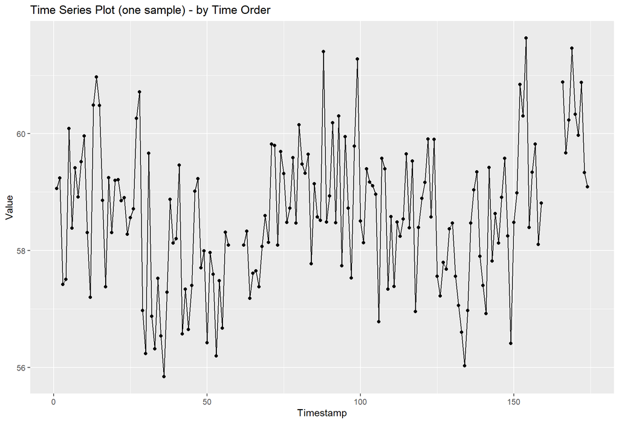

```r
# One Sample: subject - 89920960 and name - s_bp_noninvasive (d)
sample <- vitals %>%
  filter(subject == 89920960, name == "s_bp_noninvasive (d)") %>%
  mutate(time_order = row_number())

# plot by time_order
ggplot(sample, aes(x = time_order, y = value)) +
  geom_point() +
  geom_line() +
  labs(title = "Time Series Plot (one sample) - by Time Order",
       x = "Timestamp",
       y = "Value")
```

#### plot by day

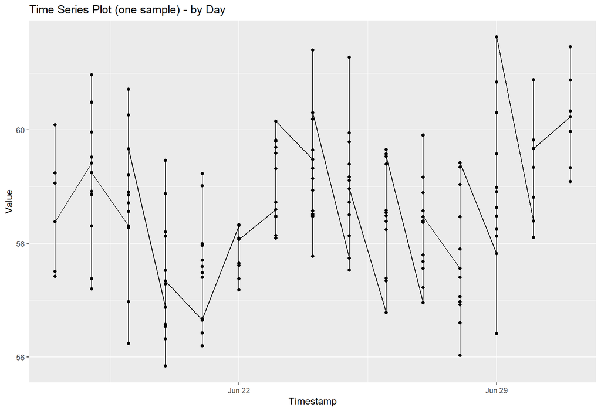

```r
# One Sample: subject - 89920960 and name - s_bp_noninvasive (d)
sample <- vitals %>%
  filter(subject == 89920960, name == "s_bp_noninvasive (d)") %>%
  mutate(time_byday = as.Date(time_stamp)) %>%
  mutate(time_order = row_number())

# plot by Day
ggplot(sample, aes(x = time_byday, y = value)) +
  geom_point() +
  geom_line() +
  labs(title = "Time Series Plot (one sample) - by Day",
       x = "Timestamp",
       y = "Value")
```

From these plots, we can see that the value fluctuated with time and the data distribution by day. Thus we consider to add statistical features such as mean value, standard deviation, and medium of values for each subject per day. This format of time (as Date) do not miss the general trend of time series. In addition, we can add trend features to capture the underlying long-term movement or behavior in the data. In this case, we do not consider seasonality trend since the time duration is short.

#### distribution plot

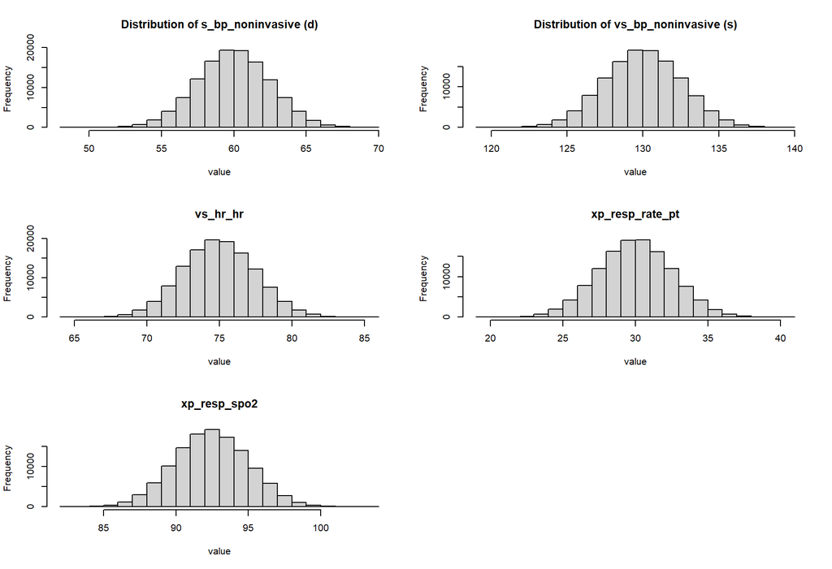

```r
name1 <- vitals %>% filter(name == "s_bp_noninvasive (d)")
name2 <- vitals %>% filter(name == "vs_bp_noninvasive (s)")
name3 <- vitals %>% filter(name == "vs_hr_hr")
name4 <- vitals %>% filter(name == "xp_resp_rate_pt")
name5 <- vitals %>% filter(name == "xp_resp_spo2")
par(mfrow = c(3, 2))
hist(name1$value, main = "Distribution of s_bp_noninvasive (d)", xlab = "value")
hist(name2$value, main = "Distribution of vs_bp_noninvasive (s)", xlab = "value")
hist(name3$value, main = "vs_hr_hr", xlab = "value")
hist(name4$value, main = "xp_resp_rate_pt", xlab = "value")
hist(name5$value, main = "xp_resp_spo2", xlab = "value")
```

From these plots, we can see that the distribution of each name category seems to be symmetric and normal shaped. Skewness and Kurtosis features are valuable descriptive statistics that helps to understand the shape and distribution of data, such as whether the distribution is symmetric and the presence of outliers. Therefore, we will add skewness and kurtosis features in the following analysis since our data seems fulfill the requirement of normalization.

### add features

```r
# change time_stamp to Date format
vitals$time_stamp <- as.Date(vitals$time_stamp)

# calculate statistical features for each patient per day
vital_features <- vitals %>%
  na.omit() %>%
  group_by(subject, time_stamp, name) %>%
  summarise(
    mean_value = mean(value, na.rm = TRUE),
    sd_value = sd(value, na.rm = TRUE),
    median_value = median(value, na.rm = TRUE)
    )
# create skewness and kurtosis features for each patient
skewness_feature <- vitals %>%
  na.omit() %>%
  group_by(subject, name) %>%
  summarise(
    skewness = skewness(value, na.rm = TRUE)
  )
kurtosis_feature <- vitals %>%
  na.omit() %>%
  group_by(subject, name) %>%
  summarise(
    kurtosis = kurtosis(value, na.rm = TRUE)
  )
# change to wider to generate unique rows
skewness_wider <- skewness_feature %>%
  select(subject, name, skewness) %>%
  unique() %>%
  pivot_wider(names_from = name, values_from = skewness)

kurtosis_wider <- kurtosis_feature %>%
  select(subject, name, kurtosis) %>%
  unique() %>%
  pivot_wider(names_from = name, values_from = kurtosis)


# create trend feature for each patient
time_order <- vital_features %>%
  arrange(time_stamp) %>% # order by time
  mutate(order = row_number()) %>% # add time order
  group_by(subject) %>%
  mutate(trend = cor(order, mean_value)) # add trend feature

# change to wider to generate unique rows
time_order_wider <- time_order %>%
  select(subject, name, trend) %>%
  unique() %>% # keep the unique combinations of subject, name, trend - collapse into a single row
  pivot_wider(names_from = name, values_from = trend) # pivot to wider

# combine features and baseline
final_data <- left_join(baselines, time_order_wider, by = "subject")
final_data <- left_join(final_data, skewness_wider, by = "subject")
final_data <- left_join(final_data, kurtosis_wider, by = "subject")
```

## Predictive Modeling

Using all baseline variables and features extracted from labs and vitals, your goal is to build a predictive model predicting the binary event of intubation within 5 days of hospitalization. You can use various learning methods for prediction and you need to compare the prediction error of the models. You need to provide detailed explanations of the steps you have taken to tune your models, estimate and compare prediction error. Finally, you have to choose a final model that you will present to the authorities and explain the prediction model the best you can to the authorities so that they understand factors are important for prediction.

#### split data into traning and testing dataset

```r
# str(final_data)
set.seed(234)
library(caret)
# delete column "subject"
final_data <- final_data %>%
  select(-subject)

# create training index
train_index <- createDataPartition(final_data$event, p = 0.7, list = FALSE)

# Split the data into training and testing sets
training_data <- final_data[train_index, ]
testing_data <- final_data[-train_index, ]
```

### Logistic Regression

Logistic Regression can be used for binary classification task.

```r
library(glmnet)
# fit model
logit_model <- glm(event ~ ., data = training_data, family = binomial)

# print summary
summary(logit_model)
```

```
##
## Call:
## glm(formula = event ~ ., family = binomial, data = training_data)
##
## Deviance Residuals:
##     Min       1Q   Median       3Q      Max
## -2.4517  -0.8928  -0.1934   0.8993   2.4385
##
## Coefficients: (4 not defined because of singularities)
##                                            Estimate Std. Error z value Pr(>|z|)
## (Intercept)                                7.695096   1.057085   7.280 3.35e-13
## age                                       -0.053322   0.005215 -10.225  < 2e-16
## sexMale                                    0.154165   0.159183   0.968 0.332805
## bmi                                       -0.126158   0.014762  -8.546  < 2e-16
## hypoxia_edYes                              0.035206   0.157172   0.224 0.822758
## smoke_vapeYes                              0.408403   0.172776   2.364 0.018090
## diabetes_mellitusYes                       0.165997   0.167352   0.992 0.321246
## hypertensionYes                            0.003713   0.157749   0.024 0.981221
## pulmonary_disease_COPDUnchecked           -0.390109   0.378493  -1.031 0.302687
## renal_disease_CKDUnchecked                 0.588047   0.406203   1.448 0.147710
## renal_disease_ESRDUnchecked               -0.052597   0.306692  -0.171 0.863831
## coronary_artery_diseaseYes                 0.048567   0.207030   0.235 0.814529
## cancerYes                                 -0.742710   0.308877  -2.405 0.016192
## any_immunosuppressionYes                   0.776483   0.512057   1.516 0.129418
## symptoms_feverUnchecked                   -0.145260   0.164333  -0.884 0.376733
## symptoms_coughUnchecked                   -0.119010   0.170906  -0.696 0.486209
## symptoms_diarrheaUnchecked                 0.122863   0.183532   0.669 0.503217
## symptoms_nauseaUnchecked                   0.238534   0.197483   1.208 0.227097
## symptoms_myalgiasUnchecked                 0.268536   0.198180   1.355 0.175414
## symptoms_dyspneaUnchecked                  0.001742   0.159862   0.011 0.991308
## chest_xray_clearUnchecked                 -0.279807   0.232498  -1.203 0.228790
## chest_xray_unilateral_infiltrateUnchecked  0.170686   0.241652   0.706 0.479982
## chest_xray_bilateral_infiltrateUnchecked  -0.453325   0.176565  -2.567 0.010244
## chest_xray_pleural_effusionUnchecked      -0.564121   0.360776  -1.564 0.117904
## duration_symptoms                         -0.057446   0.016002  -3.590 0.000331
## Ed_before_order_setYes                    -0.312868   0.160597  -1.948 0.051396
## `s_bp_noninvasive (d).x`                   0.154244   0.284870   0.541 0.588195
## xp_resp_rate_pt.x                                NA         NA      NA       NA
## `vs_bp_noninvasive (s).x`                        NA         NA      NA       NA
## vs_hr_hr.x                                       NA         NA      NA       NA
```

[output cut: 48 more lines]

```
## `s_bp_noninvasive (d)`
## `vs_bp_noninvasive (s)`
## vs_hr_hr
## xp_resp_rate_pt
## xp_resp_spo2
## ---
## Signif. codes:  0 '***' 0.001 '**' 0.01 '*' 0.05 '.' 0.1 ' ' 1
##
## (Dispersion parameter for binomial family taken to be 1)
##
##     Null deviance: 1305.4  on 941  degrees of freedom
## Residual deviance: 1011.1  on 905  degrees of freedom
## AIC: 1085.1
##
## Number of Fisher Scoring iterations: 4
```

```r
# predict on testing data
predicted_probs <- predict(logit_model, newdata = testing_data, type = "response")

# convert to binary predictions
predicted_classes <- ifelse(predicted_probs >= 0.5, 1, 0)

# Calculate the miss-classification error on the testing data
misclassification_error <- mean(predicted_classes != testing_data$event) %>% round(4)
paste("The miss-classification error of logistic model is ", misclassification_error)
```

```
## [1] "The miss-classification error of logistic model is  0.2953"
```

### Support Vector Machine

SVM can be used for binary classification with non-linear relationship.

```r
library(e1071)
# separate the predictors and outcome variable
X_train <- training_data[, -which(names(training_data) == "event")]
y_train <- training_data$event
X_test <- testing_data[, -which(names(testing_data) == "event")]
y_test <- testing_data$event

# fit svm model with cross-validation
svm_linear <- tune(svm, event ~ ., data = training_data, kernel = "linear", ranges = list(cost=c(0.001, 0.01, 0.1, 1, 5, 10)) )
# extract best cost
best_cost_linear <- svm_linear$best.parameters$cost
paste("The best cost for linear svm is ", best_cost_linear)
```

```
## [1] "The best cost for linear svm is  0.01"
```

```r
# fit svm model with best cost
svm_model <- svm(event ~ ., data = training_data, kernel = "linear", cost = best_cost_linear, gamma = 2)

# predict on test data
predicted_probs <- predict(svm_model, X_test, probability = TRUE)

# convert to binary predictions
predicted_classes <- ifelse(predicted_probs >= 0.5, 1, 0)

# Calculate the miss-classification error on the testing data
misclassification_error <- mean(predicted_classes != y_test) %>% round(4)
paste("The miss-classification error of svm model is ", misclassification_error)
```

```
## [1] "The miss-classification error of svm model is  0.263"
```

### Stepwise Selection Model

Stepwise Selection Model can be used to select a subset of features to reduce model complexity.

```r
# fit a stepwise regression model
stepwise_model <- glm(event ~ ., data = training_data, family = "binomial")

regfit.fwd <- step(stepwise_model, direction = "forward", trace = F)
summary(regfit.fwd)
```

```
##
## Call:
## glm(formula = event ~ age + sex + bmi + hypoxia_ed + smoke_vape +
##     diabetes_mellitus + hypertension + pulmonary_disease_COPD +
##     renal_disease_CKD + renal_disease_ESRD + coronary_artery_disease +
##     cancer + any_immunosuppression + symptoms_fever + symptoms_cough +
##     symptoms_diarrhea + symptoms_nausea + symptoms_myalgias +
##     symptoms_dyspnea + chest_xray_clear + chest_xray_unilateral_infiltrate +
##     chest_xray_bilateral_infiltrate + chest_xray_pleural_effusion +
##     duration_symptoms + Ed_before_order_set + `s_bp_noninvasive (d).x` +
##     xp_resp_rate_pt.x + `vs_bp_noninvasive (s).x` + vs_hr_hr.x +
##     xp_resp_spo2.x + `s_bp_noninvasive (d).y` + `vs_bp_noninvasive (s).y` +
##     vs_hr_hr.y + xp_resp_rate_pt.y + xp_resp_spo2.y + `s_bp_noninvasive (d)` +
##     `vs_bp_noninvasive (s)` + vs_hr_hr + xp_resp_rate_pt + xp_resp_spo2,
##     family = "binomial", data = training_data)
##
## Deviance Residuals:
##     Min       1Q   Median       3Q      Max
## -2.4517  -0.8928  -0.1934   0.8993   2.4385
##
## Coefficients: (4 not defined because of singularities)
##                                            Estimate Std. Error z value Pr(>|z|)
## (Intercept)                                7.695096   1.057085   7.280 3.35e-13
## age                                       -0.053322   0.005215 -10.225  < 2e-16
## sexMale                                    0.154165   0.159183   0.968 0.332805
## bmi                                       -0.126158   0.014762  -8.546  < 2e-16
## hypoxia_edYes                              0.035206   0.157172   0.224 0.822758
## smoke_vapeYes                              0.408403   0.172776   2.364 0.018090
## diabetes_mellitusYes                       0.165997   0.167352   0.992 0.321246
## hypertensionYes                            0.003713   0.157749   0.024 0.981221
## pulmonary_disease_COPDUnchecked           -0.390109   0.378493  -1.031 0.302687
## renal_disease_CKDUnchecked                 0.588047   0.406203   1.448 0.147710
## renal_disease_ESRDUnchecked               -0.052597   0.306692  -0.171 0.863831
## coronary_artery_diseaseYes                 0.048567   0.207030   0.235 0.814529
## cancerYes                                 -0.742710   0.308877  -2.405 0.016192
## any_immunosuppressionYes                   0.776483   0.512057   1.516 0.129418
## symptoms_feverUnchecked                   -0.145260   0.164333  -0.884 0.376733
## symptoms_coughUnchecked                   -0.119010   0.170906  -0.696 0.486209
## symptoms_diarrheaUnchecked                 0.122863   0.183532   0.669 0.503217
## symptoms_nauseaUnchecked                   0.238534   0.197483   1.208 0.227097
```

[output cut: 60 more lines]

```
## `s_bp_noninvasive (d)`
## `vs_bp_noninvasive (s)`
## vs_hr_hr
## xp_resp_rate_pt
## xp_resp_spo2
## ---
## Signif. codes:  0 '***' 0.001 '**' 0.01 '*' 0.05 '.' 0.1 ' ' 1
##
## (Dispersion parameter for binomial family taken to be 1)
##
##     Null deviance: 1305.4  on 941  degrees of freedom
## Residual deviance: 1011.1  on 905  degrees of freedom
## AIC: 1085.1
##
## Number of Fisher Scoring iterations: 4
```

```r
# make predictions on testing data
pred_label_fwd <- ifelse(predict(regfit.fwd, newdata = testing_data, type = "response") > 0.5, 1, 0)

# Calculate the miss-classification error on the testing data
misclassification_error <- mean(pred_label_fwd != y_test) %>% round(4)
paste("The miss-classification error of forward selection model is ", misclassification_error)
```

```
## [1] "The miss-classification error of forward selection model is  0.2953"
```

### Lasso Regression

LASSO regression incorporates regularizartion to improve the model’s performance and feature selection.

```r
# separate the predictors and label
x <- model.matrix(event ~., training_data)[,-1] # remove the first column - subject
y <- training_data$event
x_test <- model.matrix(event ~., testing_data)[,-1]

# fit model
lambda_lasso <- cv.glmnet(x, y, family = "binomial", nfolds = 10, alpha = 1)
regfit.lasso <- glmnet(x, y, family = "binomial", alpha = 1, lambda = lambda_lasso$lambda.min)
coef(regfit.lasso)
```

```
## 41 x 1 sparse Matrix of class "dgCMatrix"
##                                                    s0
## (Intercept)                                6.40446212
## age                                       -0.04655235
## sexMale                                    0.01044558
## bmi                                       -0.10826329
## hypoxia_edYes                              .
## smoke_vapeYes                              0.24270897
## diabetes_mellitusYes                       0.06833390
## hypertensionYes                            .
## pulmonary_disease_COPDUnchecked           -0.03987181
## renal_disease_CKDUnchecked                 0.22804787
## renal_disease_ESRDUnchecked                .
## coronary_artery_diseaseYes                 .
## cancerYes                                 -0.48857760
## any_immunosuppressionYes                   0.32092687
## symptoms_feverUnchecked                   -0.02704467
## symptoms_coughUnchecked                    .
## symptoms_diarrheaUnchecked                 .
## symptoms_nauseaUnchecked                   0.09121908
## symptoms_myalgiasUnchecked                 0.12661845
## symptoms_dyspneaUnchecked                  .
## chest_xray_clearUnchecked                 -0.04786784
## chest_xray_unilateral_infiltrateUnchecked  .
## chest_xray_bilateral_infiltrateUnchecked  -0.32448932
## chest_xray_pleural_effusionUnchecked      -0.19696064
## duration_symptoms                         -0.04238632
## Ed_before_order_setYes                    -0.17185273
## `s_bp_noninvasive (d).x`                   .
## xp_resp_rate_pt.x                          .
## `vs_bp_noninvasive (s).x`                  .
## vs_hr_hr.x                                 .
## xp_resp_spo2.x                             .
## `s_bp_noninvasive (d).y`                   .
## `vs_bp_noninvasive (s).y`                  0.48347103
## vs_hr_hr.y                                 0.42667297
## xp_resp_rate_pt.y                         -0.06630965
## xp_resp_spo2.y                             .
## `s_bp_noninvasive (d)`                     .
## `vs_bp_noninvasive (s)`                    0.05541675
## vs_hr_hr                                   .
## xp_resp_rate_pt                            .
## xp_resp_spo2                               0.12516291
```

```r
# predict on test data
pred_label_lasso <- ifelse(predict(regfit.lasso, newx = as.matrix(x_test), type = "response") > 0.5, 1, 0)

# Calculate the miss-classification error on the testing data
misclassification_error <- mean(pred_label_lasso != y_test) %>% round(4)
paste("The miss-classification error of LASSO model is ", misclassification_error)
```

```
## [1] "The miss-classification error of LASSO model is  0.2506"
```

## Conclusion:

By fitting predictive models including Logistic Regression, Support Vector Machine, Stepwise Selection Model and Lasso Regression with cross validation. The miss classification error of LASSO Regression is the smallest, which is 0.2506, indicating that this model has the best performance on predicting the binary event outcome.

And the effective biomarkers from baselines include: age, sex, bmi, smoke_vape, diabetes_mellitus, pulmonary_disease_COPD, renal_disease_CKD, cancer, any_immunosuppression, symptoms_fever, symptoms_nausea, symptoms_myalgias, chest_xray_clear, chest_xray_bilateral_infiltrate, chest_xray_pleural_effusion, duration_symptoms and Ed_before_order_se.